# More Bootstrapping

Mark Schulist

2022-11-04

We are guessing the proportion of American youth age 8-18 have a screen in their bedroom. We found that the 80% interval is narrower than the 99% interval. *The more confident we want to be, the wider the interval needs to be.*

He’s how much sleep we got last night.

```r
sleep <- c(8.25, 5.75, 6.5, 6.5, 7.5, 8.5, 7.5, 6, 7.5, 7, 7.25, 8.75, 8, 8.5, 8, 8.5, 8.5)
```

n = 17

mean = 7.5588235

sd = 0.9417794

Now, I’ll generate 10000 samples with replacement.

```r
thousand_samples <- replicate(10000,
  mean(sample(sleep, length(sleep), replace = T)))
```

Here’s some stats of the bootstrap distribution.

mean = 7.5607632

sd = 0.2200376

Here’s the confidence interval for the t-chart.

```r
upper <- mean(sleep) + 2*sd(thousand_samples)
lower <- mean(sleep) - 2*sd(thousand_samples)
```

Confidence interval: (7.1187, 7.9989)

Here’s a graph of the t-chart.

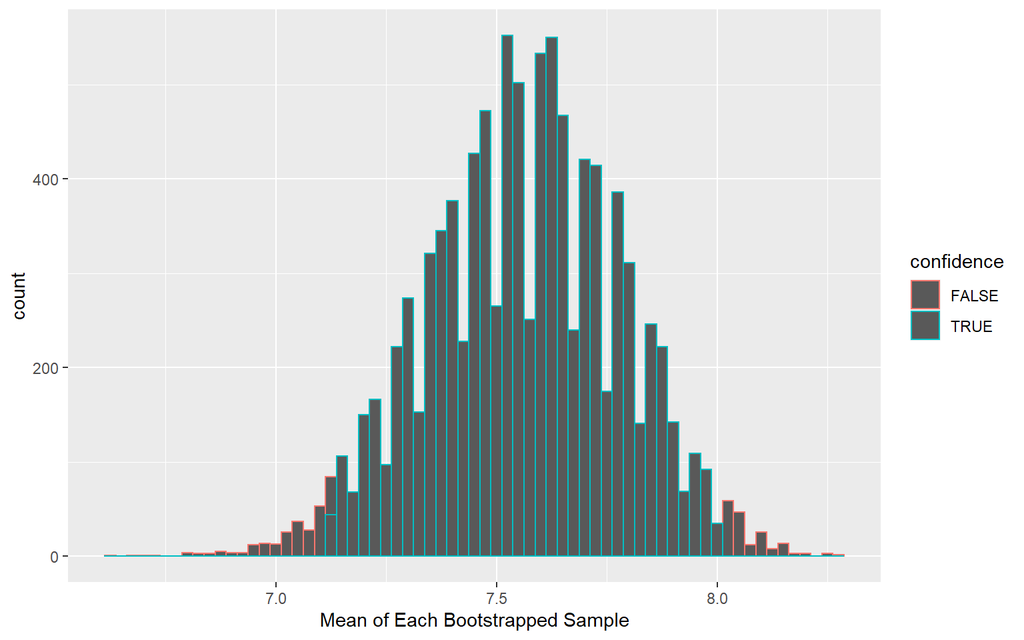

```r
thousand_tbl <- thousand_samples %>% as_tibble() %>%
  rename(t_vals = 1) %>%
  mutate(
  confidence = (t_vals <= mean(t_vals) + 2 * sd(t_vals)) &
    (t_vals >= mean(t_vals) - 2 * sd(t_vals))
)
ggplot(thousand_tbl, aes(t_vals)) +
  geom_histogram(aes(color = confidence), binwidth = 0.025) +
  xlab("Mean of Each Bootstrapped Sample")
```

Misinterpretations:

Confidence intervals do NOT care about the data, only the mean of each sample.

The sample mean will always be inside of the confidence interval. The confidence interval shows us the true mean of the population, not the mean of the sample.

The confidence interval is not a 0.95 probability.

The confidence interval contains the true mean (ideally).

# Using our confidence interval to determine the p value

$$\begin{align*}
H_0{:\hspace{0.2cm}} \mu = 8 \\
H_a{:\hspace{0.2cm}} \mu > 8
\end{align*}$$

If our 8 hours is within the confidence interval, then we accept the null hypothesis. Any number inside the confidence interval is expected to happen (more than 0.05 chance of it happening).

Now we can find the outside 5% of the data using the empirical values instead of the sd values.

```r
empirical <- quantile(thousand_samples, c(0.025, 0.975))
lower_emp <- empirical[1]
upper_emp <- empirical[2]
```

Confidence interval = (7.132, 7.971)

# Recap

If the level of confidence increases, then the interval gets wider. Like going from a 95% confidence to a 99% will make the interval wider.

If the sample size increases, then the interval gets narrower. So if we had 40 people in our class, the 95% confidence interval would have been narrower.